# Cerebral Stroke Diagnosis based on physiological Factors

### Data Analysis for Ever Married

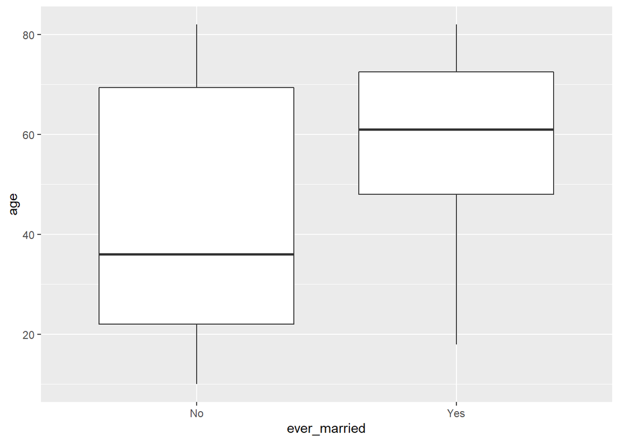

```r
ggplot(data = recycleData, mapping = aes(x = ever_married, y = age)) +
  geom_boxplot()
```

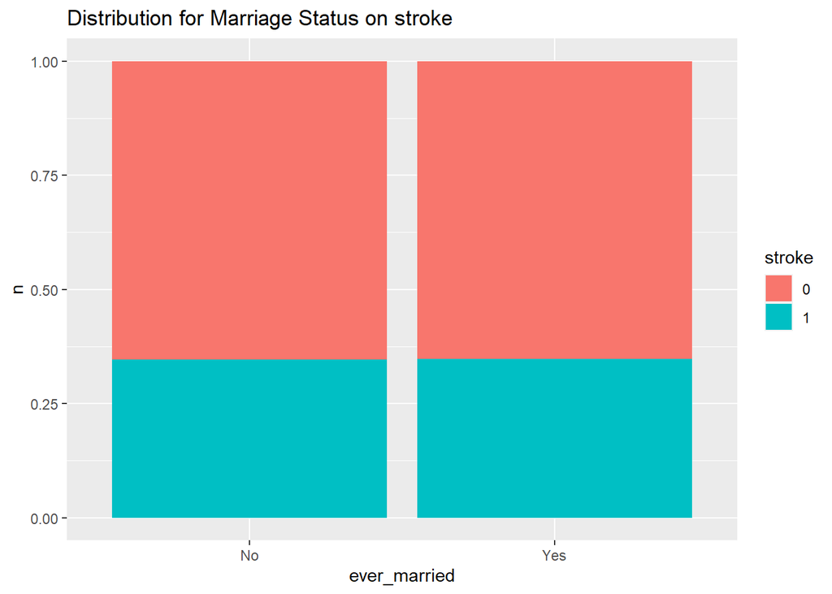

```r
select_married <- select(recycleData, c('ever_married','stroke'))

married_effect <-
  select_married %>%
  group_by(ever_married, stroke) %>%
  count(stroke)

ggplot(married_effect, aes(ever_married, n, fill = stroke)) +
  geom_bar(stat = 'identity', position='fill') +
  ggtitle("Distribution for Marriage Status on stroke")
```

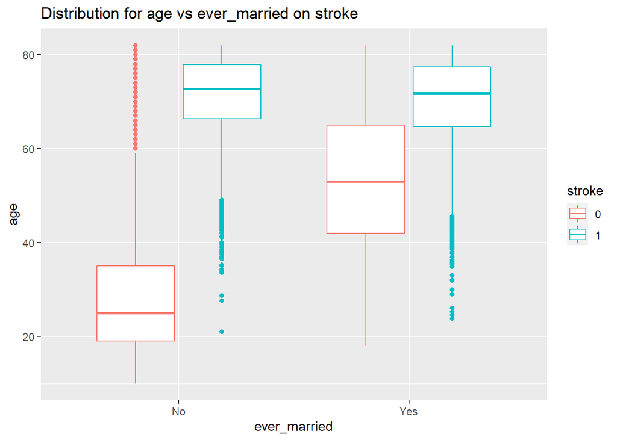

```r
ggplot(recycleData, aes(ever_married, age, color = stroke)) +
  geom_boxplot() +
  ggtitle("Distribution for age vs ever_married on stroke")
```

### Data Analysis for Smoking Status

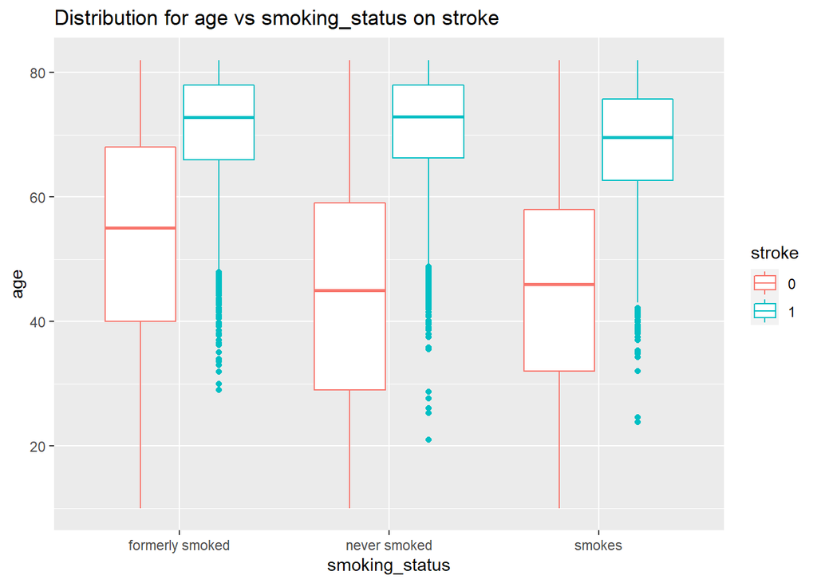

```r
no_na_for_smoking_status <- subset(recycleData, !is.na(smoking_status))

ggplot(no_na_for_smoking_status, aes(smoking_status, age, color = stroke)) +
  geom_boxplot() +
  ggtitle("Distribution for age vs smoking_status on stroke")
```

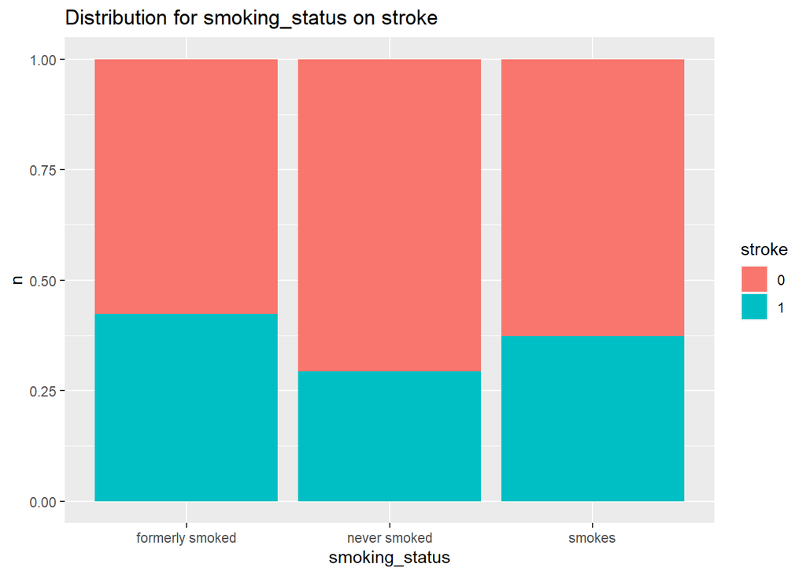

```r
select_smoke <- select(no_na_for_smoking_status, c('smoking_status','stroke'))

smoke_effect <- select_smoke %>%
  group_by(smoking_status, stroke) %>%
  count(stroke)

ggplot(smoke_effect, aes(smoking_status, n, fill = stroke)) +
  geom_bar(stat = 'identity', position='fill') +
  ggtitle("Distribution for smoking_status on stroke")
```

After the analysis of smoking status against stroke where `0` is `No` and `1` is `Yes`, we notice that smoking status does not really have an effect on stroke. According to the graph, we see that people who formerly smoked have more tendency to get strokes than people who never smoked and are still smoking. The boxplot distribution then shows that age is indeed has a great effect on stroke, we see that people approximately above 60 and formerly smoked have strokes under a normal distribution and younger people across all distribution do not have strokes.

**Data Analysis for Gender**

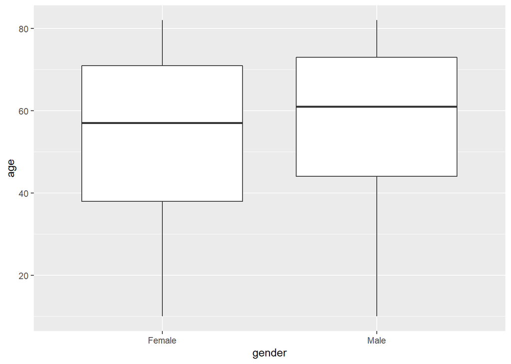

```r
ggplot(data = recycleData, mapping = aes(x = gender, y = age)) +
  geom_boxplot()
```

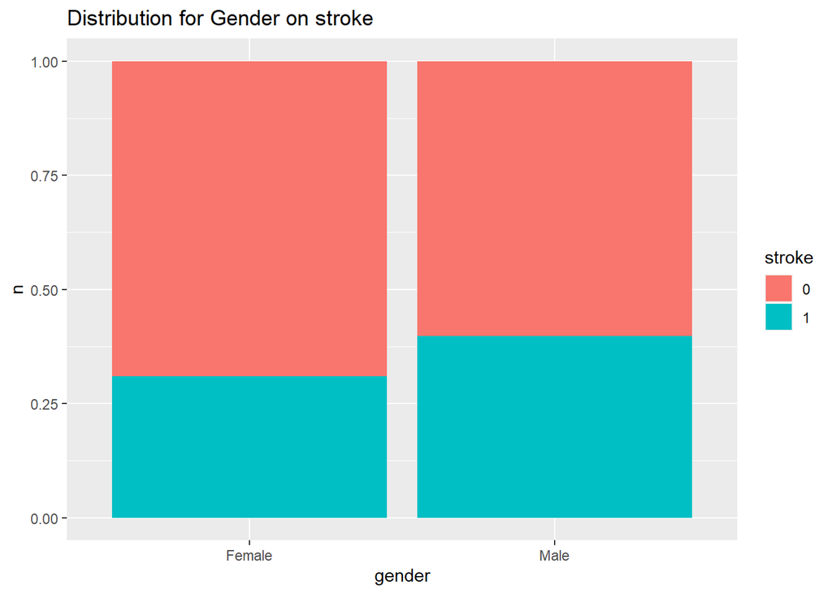

```r
select_gender <- select(recycleData, c('gender','stroke'))
gender_effect <- select_gender %>%
  group_by(gender, stroke) %>%
  count(stroke)

ggplot(gender_effect, aes(gender, n, fill = stroke)) +
  geom_bar(stat = 'identity', position='fill') +
  ggtitle("Distribution for Gender on stroke")
```

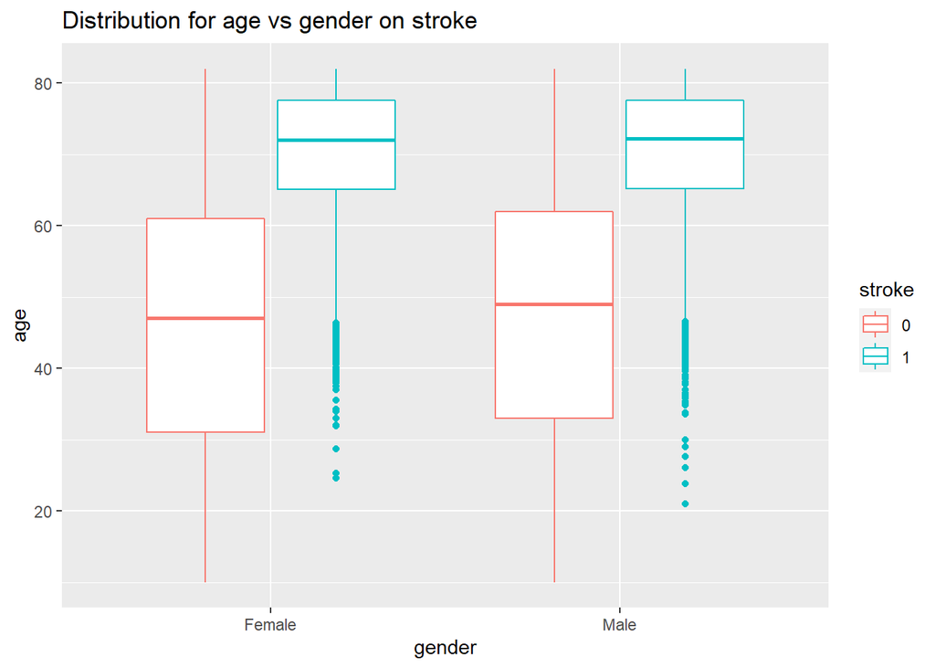

```r
ggplot(recycleData, aes(gender, age, color = stroke)) +
  geom_boxplot() +
  ggtitle("Distribution for age vs gender on stroke")
```

The plots we see above indicates that if we are looking at gender alone as a factor for strokes, males are more likely to get strokes that females but this does not really prove to be a strong effect on stroke. We then plot gender with age against strokes and notice the same result we have been getting, all evidence point to age i.e Age is a huge factor to determining if an individual is prone to stroke.

### Data Analysis for Work Type

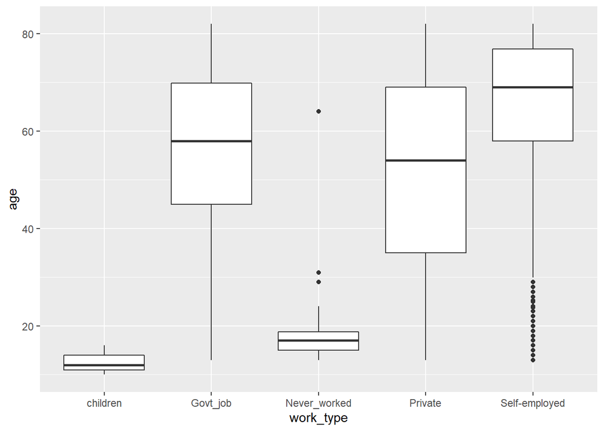

```r
ggplot(data = recycleData, mapping = aes(x = work_type, y = age)) +
  geom_boxplot()
```

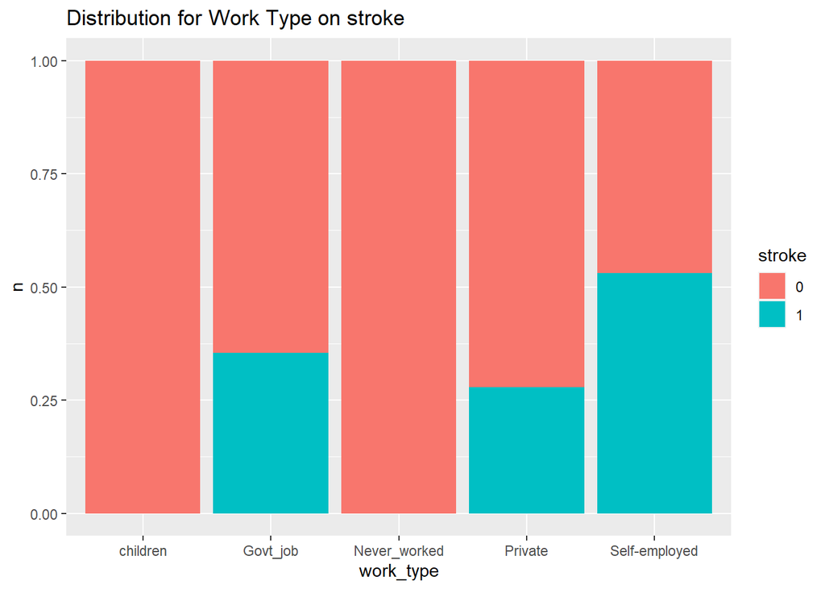

```r
select_work <- select(recycleData, c('work_type','stroke'))
workType_effect <- select_work %>%
  group_by(work_type, stroke) %>%
  count(stroke)

ggplot(workType_effect, aes(work_type, n, fill = stroke)) +
  geom_bar(stat = 'identity', position='fill') +
  ggtitle("Distribution for Work Type on stroke")
```

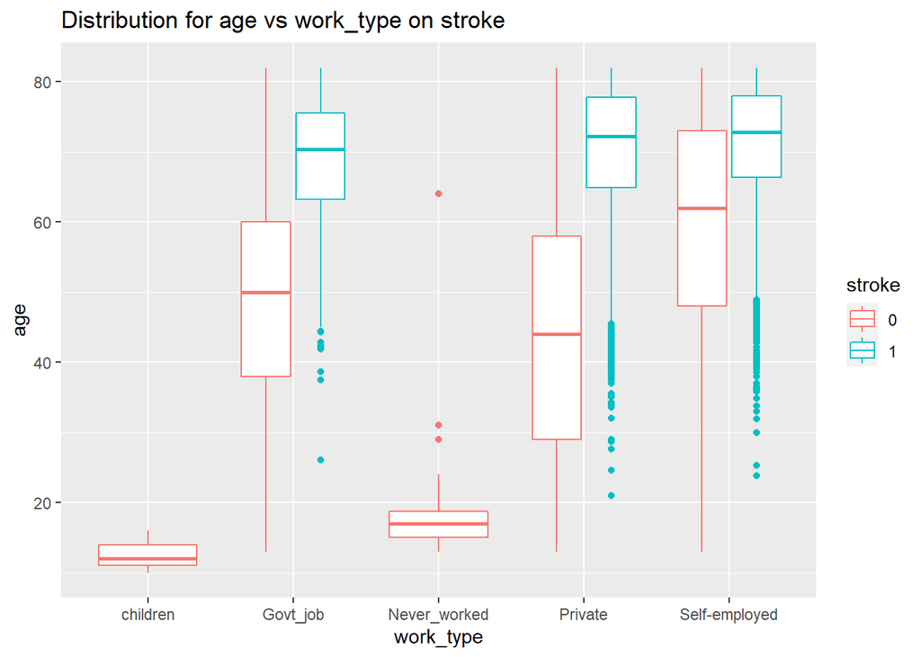

```r
ggplot(recycleData, aes(work_type, age, color = stroke)) +
  geom_boxplot() +
  ggtitle("Distribution for age vs work_type on stroke")
```

From the box plot people with govt_job, private and self-employed are more likely to get heart stroke. But when comparing with age, this might be because people who have stroke in these 3 categories are older.  
So age might be contributing to this dependence.

### Chi square Testing to check independence of variable

```r
chisquare_for_dataset <- function(df) {     # defined a function to call chisquare test on different datasets. Created this function as it is getting called twice
contable_gender = table(df$gender, df$stroke)
contable_age = table(df$age, df$stroke)
contable_hypertension = table(df$hypertension, df$stroke)
contable_heart_disease = table(df$heart_disease, df$stroke)
contable_ever_married = table(df$ever_married, df$stroke)
contable_work_type = table(df$work_type, df$stroke)
contable_Residence_type = table(df$Residence_type, df$stroke)
contable_avg_glucose_level = table(df$avg_glucose_level, df$stroke)
contable_bmi = table(df$bmi, df$stroke)
contable_smoking_status = table(df$smoking_status, df$stroke)
contable_glucose_group = table(df$glucoseGroup)

chitest_gender = chisq.test(contable_gender)
chitest_age = chisq.test(contable_age)
chitest_hypertension = chisq.test(contable_hypertension)
chitest_heart_disease = chisq.test(contable_heart_disease)
chitest_ever_married = chisq.test(contable_ever_married)
chitest_work_type = chisq.test(contable_work_type)
chitest_Residence_type = chisq.test(contable_Residence_type)
chitest_avg_glucose_level = chisq.test(contable_avg_glucose_level)
chitest_bmi = chisq.test(contable_bmi)
chitest_smoking_status = chisq.test(contable_smoking_status)
chitest_glucose_group = chisq.test(contable_glucose_group)


print(chitest_gender)
print(chitest_age)
print(chitest_hypertension)
print(chitest_heart_disease)
print(chitest_ever_married)
print(chitest_work_type)
print(chitest_Residence_type)
print(chitest_avg_glucose_level)
print(chitest_bmi)
print(chitest_smoking_status)
print(chitest_glucose_group)

}
```

```r
print("For up sampled dataset")
```

```
## [1] "For up sampled dataset"
```

```r
chisquare_for_dataset(cleanData)
```

```
##
##  Pearson's Chi-squared test
##
## data:  contable_gender
## X-squared = NaN, df = 2, p-value = NA
##
##
##  Pearson's Chi-squared test
##
## data:  contable_age
## X-squared = 32785, df = 11751, p-value < 2.2e-16
##
##
##  Pearson's Chi-squared test with Yates' continuity correction
##
## data:  contable_hypertension
## X-squared = 5581.5, df = 1, p-value < 2.2e-16
##
##
##  Pearson's Chi-squared test with Yates' continuity correction
##
## data:  contable_heart_disease
## X-squared = 8057.9, df = 1, p-value < 2.2e-16
##
##
##  Pearson's Chi-squared test with Yates' continuity correction
##
## data:  contable_ever_married
## X-squared = 0.021588, df = 1, p-value = 0.8832
##
##
##  Pearson's Chi-squared test
##
## data:  contable_work_type
## X-squared = 2133.3, df = 4, p-value < 2.2e-16
##
##
##  Pearson's Chi-squared test with Yates' continuity correction
##
## data:  contable_Residence_type
```

[output cut: 10 more lines]

```
##
## data:  contable_bmi
## X-squared = 33663, df = 12322, p-value < 2.2e-16
##
##
##  Pearson's Chi-squared test
##
## data:  contable_smoking_status
## X-squared = NaN, df = 3, p-value = NA
##
##
##  Chi-squared test for given probabilities
##
## data:  contable_glucose_group
## X-squared = 16992, df = 2, p-value < 2.2e-16
```

### TTEST to check similarity of distributions

```r
subset_stroke_1 = subset(cleanData, cleanData$stroke == 1)
subset_stroke_0 = subset(cleanData, cleanData$stroke == 0)


ttest2sample_age = t.test(subset_stroke_1$age, subset_stroke_0$age)
ttest2sample_bmi = t.test(subset_stroke_1$bmi, subset_stroke_0$bmi)
ttest2sample_glucose = t.test(subset_stroke_1$avg_glucose_level, subset_stroke_0$avg_glucose_level)

print(ttest2sample_age)
```

```
##
##  Welch Two Sample t-test
##
## data:  subset_stroke_1$age and subset_stroke_0$age
## t = 162.22, df = 36506, p-value < 2.2e-16
## alternative hypothesis: true difference in means is not equal to 0
## 95 percent confidence interval:
##  22.85307 23.41206
## sample estimates:
## mean of x mean of y
##  70.27197  47.13940
```

```r
print(ttest2sample_bmi)
```

```
##
##  Welch Two Sample t-test
##
## data:  subset_stroke_1$bmi and subset_stroke_0$bmi
## t = 1.4856, df = 34129, p-value = 0.1374
## alternative hypothesis: true difference in means is not equal to 0
## 95 percent confidence interval:
##  -0.02549006  0.18510809
## sample estimates:
## mean of x mean of y
##  29.29778  29.21797
```

```r
print(ttest2sample_glucose)
```

```
##
##  Welch Two Sample t-test
##
## data:  subset_stroke_1$avg_glucose_level and subset_stroke_0$avg_glucose_level
## t = 69.42, df = 24593, p-value < 2.2e-16
## alternative hypothesis: true difference in means is not equal to 0
## 95 percent confidence interval:
##  29.28509 30.98687
## sample estimates:
## mean of x mean of y
##  131.7343  101.5983
```

**Age TTEST**  
*NULL hypothesis*: Means of age with subjects having stroke and not having stroke are same i.e. same distributions.  
*Alternate Hypothesis*: Means of age with subjects having stroke and not having stroke are different i.e. different distributions.  
Pvalue is very small so we can reject the NULL hypothesis. So age with stroke and age without stroke have different distributions.

**BMI TTEST**  
*NULL hypothesis*: Means of BMI values with subjects having stroke and not having stroke are same i.e. same distributions.  
*Alternate Hypothesis*: Means of BMI values with subjects having stroke and not having stroke are different i.e. different distributions.  
Pvalue is not small so we cannot reject the NULL hypothesis. So BMI with stroke and BMI without stroke have same distributions.

**Glucose level TTEST**  
*NULL hypothesis*: Means of glucose levels with subjects having stroke and not having stroke are same i.e. same distributions.  
*Alternate Hypothesis*: Means of glucose levels with subjects having stroke and not having stroke are different i.e. different distributions.  
Pvalue is very small so we can reject the NULL hypothesis. So glucose levels with stroke and glucose levels without stroke have different distributions.